# US Carrier Performance (2009-2019)

## by Anuja Jadhav

## Investigation Overview

Which carrier(s) has shown consistently good performance with respect to carrier delay,arrival diversions, arrival cancellations for 10 years (2009 to 2019)?

## Dataset Overview

The data contains 174498 entries for 23 airlines describing the flight delay statistics over 10 years (Jan 2009 to Dec 2019) flying in United States.

For the fairness of analysis, only the airlines which flew more than 8 years between 2009 and 2019 are chosen. Each performance KPI is normalized into a ratio (KPI / total flight arrivals for an airline ) to generate 4 new KPIs:

1. Cancellation Ratio = Total Cancellation of the carrier in the year / Total Flight arrivals in the year
2. Diversion Ratio = Total Diversion of the carrier in the year / Total Flight arrivals in the year
3. Carrier Delay Ratio = Total Number of Carrier Delay of the carrier in the year / Total Flight arrivals in the year
4. Average Carrier Delay (Minutes) Ratio = Total Carrier Delay minutes of the carrier in the year / Total Carrier Delays in the year

## Carrier Cancellation Ratio Over Years

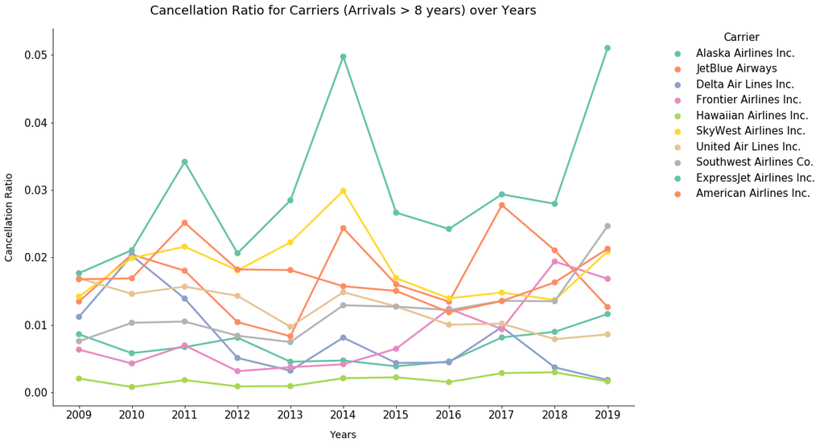

```python
ct_counts = df.groupby(['carrier_name', 'year']).size()

# Use Series.reset_index() to convert a series into a dataframe object
ct_counts = ct_counts.reset_index(name='count')

res = ct_counts.pivot(index='carrier_name', columns='year', values='count')

res = pd.DataFrame(res.fillna(0))

res['Total'] = res[2009] + res[2010] + res[2011] + res[2012] + res[2013] + res[2014] + res[2015] + res[2016] + res[2017] + res[2018] + res[2019]

#creation of subset A
subset_a = res.query('Total >= 8').index
subset_a=np.array(subset_a)

plt.figure(figsize=[15, 10])

df_a=df[df.carrier_name.isin(subset_a)]

sb.pointplot(data=df_a,x='year',y='cancellation_r',errwidth=False,hue='carrier_name',palette='Set2')
sb.despine(bottom = False, left = False)

plt.title('Cancellation Ratio for Carriers (Arrivals > 8 years) over Years')

plt.xlabel('Years')

plt.ylabel('Cancellation Ratio')

# Put the legend out of the figure
plt.legend(title='Carrier',bbox_to_anchor=(1.05, 1), loc=2, borderaxespad=0.);
```

## Carrier Diversion Ratio Over Years

> Once more, we observe Hawaiian airlines has lowest carrier diversion. Frontier Airlines has the second all time lowest carrier diversion, however, there is the huge gap between Frontier and Hawaiin airlines, showing they have a lot to catch-up. Although American Airlines, was performing worst from 2009 till 2014, they significantly managed to drop their flight diversions from 2015. SkyWest Airlines show an alarming flight diversion rate from 2012, making it divering the most in 2019 in comparison with other carriers.

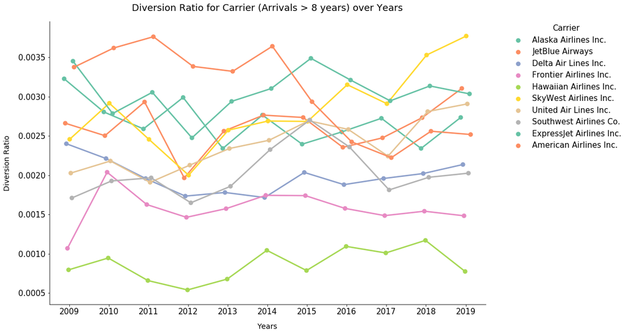

```python
plt.figure(figsize=[15, 10])

df_a=df[df.carrier_name.isin(subset_a)]

sb.pointplot(data=df_a,x='year',y='diverted_r',errwidth=False,hue='carrier_name',dodge=True,palette='Set2')
sb.despine(bottom = False, left = False)

plt.title('Diversion Ratio for Carrier (Arrivals > 8 years) over Years')

plt.xlabel('Years')

plt.ylabel('Diversion Ratio')

# Put the legend out of the figure
plt.legend(title='Carrier',bbox_to_anchor=(1.05, 1), loc=2, borderaxespad=0.);
```

## Carrier Delay Ratio Over Years

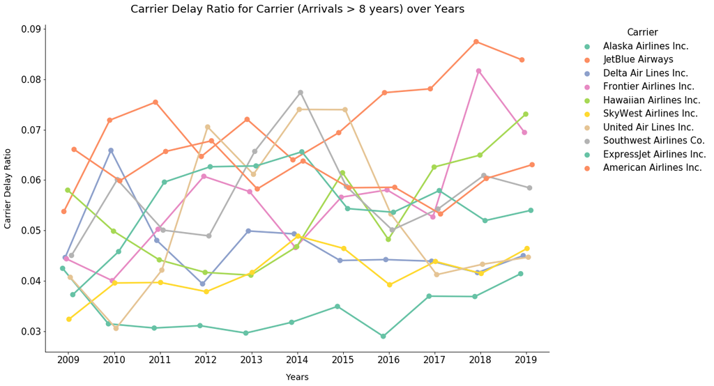

```python
plt.figure(figsize=[15, 10])

df_a=df[df.carrier_name.isin(subset_a)]

sb.pointplot(data=df_a,x='year',y='cdelayed_r',errwidth=False,hue='carrier_name',dodge=True,palette='Set2')
sb.despine(bottom = False, left = False)

plt.title('Carrier Delay Ratio for Carrier (Arrivals > 8 years) over Years')

plt.xlabel('Years')

plt.ylabel('Carrier Delay Ratio')

# Put the legend out of the figure
plt.legend(title='Carrier',bbox_to_anchor=(1.05, 1), loc=2, borderaxespad=0.);
```

## Average Carrier Delay(in minutes) Over Years

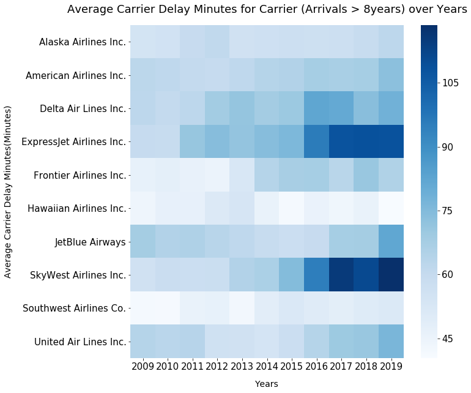

```python
plt.figure(figsize=[10, 10])

#Create a pivot to plot a heat map
df_a=df[df.carrier_name.isin(subset_a)]
df_a = df_a[["carrier_name","year","cdelayed_min_avg"]]
data_pivoted = df_a.pivot("carrier_name","year","cdelayed_min_avg")
ax = sb.heatmap(data_pivoted, annot=False,cmap="Blues")

plt.title('Average Carrier Delay Minutes for Carrier (Arrivals > 8years) over Years')

plt.xlabel('Years')

plt.ylabel('Average Carrier Delay Minutes(Minutes)')

plt.show();
```

## Conclusion

Which carrier(s) has shown consistently good performance with respect to carrier delay,arrival diversions, arrival cancellations for 10 years (2009 to 2019)?

1. All time Lowest Average Carrier Delay Minutes: Hawaiian Airlines
2. All time Lowest Number of Carrier Delays: Alaska Airlines
3. All time Lowest Cancellation Ratio: Hawaiian Airlines
4. All time Lowest Diversion Ratio: Hawaiian Airlines